# Project: Investigate a Dataset - [No-show- appointments]

- Introduction
- Data Wrangling
- Exploratory Data Analysis
- Conclusions

## Introduction

In this dataset, I will discuss the factors affecting the absence and the presence of the patients. what exactly may have helped the patients be on their schedualed time ?, what are the factors contributing to the absence of others?.

```python
# Use this cell to set up import statements for all of the packages that you
#   plan to use.

# Remember to include a 'magic word' so that your visualizations are plotted
#   inline with the notebook. See this page for more:
#   http://ipython.readthedocs.io/en/stable/interactive/magics.html
import pandas as pd
import numpy as np
import matplotlib.pyplot as plt
import seaborn as sns
% matplotlib inline
```

```python
# Upgrade pandas to use dataframe.explode() function.
!pip install --upgrade pandas==0.25.0
```

[output not shown]

## Data Wrangling

```python
df = pd.read_csv('data.csv')
df.head()
```

|  | PatientId | AppointmentID | Gender | ScheduledDay | AppointmentDay | Age | Neighbourhood | Scholarship | Hipertension | Diabetes | Alcoholism | Handcap | SMS_received | No-show |
| --- | --- | --- | --- | --- | --- | --- | --- | --- | --- | --- | --- | --- | --- | --- |
| 0 | 2.987250e+13 | 5642903 | F | 2016-04-29T18:38:08Z | 2016-04-29T00:00:00Z | 62 | JARDIM DA PENHA | 0 | 1 | 0 | 0 | 0 | 0 | No |
| 1 | 5.589978e+14 | 5642503 | M | 2016-04-29T16:08:27Z | 2016-04-29T00:00:00Z | 56 | JARDIM DA PENHA | 0 | 0 | 0 | 0 | 0 | 0 | No |
| 2 | 4.262962e+12 | 5642549 | F | 2016-04-29T16:19:04Z | 2016-04-29T00:00:00Z | 62 | MATA DA PRAIA | 0 | 0 | 0 | 0 | 0 | 0 | No |
| 3 | 8.679512e+11 | 5642828 | F | 2016-04-29T17:29:31Z | 2016-04-29T00:00:00Z | 8 | PONTAL DE CAMBURI | 0 | 0 | 0 | 0 | 0 | 0 | No |
| 4 | 8.841186e+12 | 5642494 | F | 2016-04-29T16:07:23Z | 2016-04-29T00:00:00Z | 56 | JARDIM DA PENHA | 0 | 1 | 1 | 0 | 0 | 0 | No |

I noticed multiple problems with the dataset : 1.some column labels need to be changed (handcap, No-show) 2.ScheduledDay and AppointmentDay need to be changed to int 3.patientId need to be changed to int

```python
df.info()
```

```
<class 'pandas.core.frame.DataFrame'>
RangeIndex: 110527 entries, 0 to 110526
Data columns (total 14 columns):
PatientId         110527 non-null float64
AppointmentID     110527 non-null int64
Gender            110527 non-null object
ScheduledDay      110527 non-null object
AppointmentDay    110527 non-null object
Age               110527 non-null int64
Neighbourhood     110527 non-null object
Scholarship       110527 non-null int64
Hipertension      110527 non-null int64
Diabetes          110527 non-null int64
Alcoholism        110527 non-null int64
Handcap           110527 non-null int64
SMS_received      110527 non-null int64
No-show           110527 non-null object
dtypes: float64(1), int64(8), object(5)
memory usage: 11.8+ MB
```

Looking at the statistics of the dataset : 1.The minimum age is -1 which is not right logically.

```python
df.describe()
```

|  | PatientId | AppointmentID | Age | Scholarship | Hipertension | Diabetes | Alcoholism | Handcap | SMS_received |
| --- | --- | --- | --- | --- | --- | --- | --- | --- | --- |
| count | 1.105270e+05 | 1.105270e+05 | 110527.000000 | 110527.000000 | 110527.000000 | 110527.000000 | 110527.000000 | 110527.000000 | 110527.000000 |
| mean | 1.474963e+14 | 5.675305e+06 | 37.088874 | 0.098266 | 0.197246 | 0.071865 | 0.030400 | 0.022248 | 0.321026 |
| std | 2.560949e+14 | 7.129575e+04 | 23.110205 | 0.297675 | 0.397921 | 0.258265 | 0.171686 | 0.161543 | 0.466873 |
| min | 3.921784e+04 | 5.030230e+06 | -1.000000 | 0.000000 | 0.000000 | 0.000000 | 0.000000 | 0.000000 | 0.000000 |
| 25% | 4.172614e+12 | 5.640286e+06 | 18.000000 | 0.000000 | 0.000000 | 0.000000 | 0.000000 | 0.000000 | 0.000000 |
| 50% | 3.173184e+13 | 5.680573e+06 | 37.000000 | 0.000000 | 0.000000 | 0.000000 | 0.000000 | 0.000000 | 0.000000 |
| 75% | 9.439172e+13 | 5.725524e+06 | 55.000000 | 0.000000 | 0.000000 | 0.000000 | 0.000000 | 0.000000 | 1.000000 |
| max | 9.999816e+14 | 5.790484e+06 | 115.000000 | 1.000000 | 1.000000 | 1.000000 | 1.000000 | 4.000000 | 1.000000 |

Filtering to find the exact column where there is a negative value in the age.

```python
df.query('Age == -1')
```

|  | PatientId | AppointmentID | Gender | ScheduledDay | AppointmentDay | Age | Neighbourhood | Scholarship | Hipertension | Diabetes | Alcoholism | Handcap | SMS_received | No-show |
| --- | --- | --- | --- | --- | --- | --- | --- | --- | --- | --- | --- | --- | --- | --- |
| 99832 | 4.659432e+14 | 5775010 | F | 2016-06-06T08:58:13Z | 2016-06-06T00:00:00Z | -1 | ROMÃO | 0 | 0 | 0 | 0 | 0 | 0 | No |

Checking if there are any duplication.

```python
df.duplicated().values.any()
```

```
False
```

Checking if there are any missing values.

```python
df.isnull().values.any()
```

```
False
```

### Data Cleaning

```python
df['PatientId']= df['PatientId'].astype(int)
```

Changing the appointment day to datetime format for easier manipulation.

```python
df['AppointmentDay'] = pd.to_datetime(df['AppointmentDay']).dt.date
```

Changing the ScheduledDay to datetime format for easier manipulation.

```python
df['ScheduledDay'] = pd.to_datetime(df['ScheduledDay']).dt.date
```

Renaming the colums for better coding (No-show to No_show) and correcting the spelling mistakes.

```python
df.rename(columns={'Handcap':'Handicap','No-show':'No_show','Hipertension':'Hypertension'}, inplace = True)
```

```python
df.drop(99832, axis = 0 , inplace = True)
```

Checking if it is deleted.

```python
df.query('Age == -1')
```

|  | PatientId | AppointmentID | Gender | ScheduledDay | AppointmentDay | Age | Neighbourhood | Scholarship | Hypertension | Diabetes | Alcoholism | Handicap | SMS_received | No_show |
| --- | --- | --- | --- | --- | --- | --- | --- | --- | --- | --- | --- | --- | --- | --- |

Checking the dataset one more time to see if the changes are still there.

```python
df.head()
```

|  | PatientId | AppointmentID | Gender | ScheduledDay | AppointmentDay | Age | Neighbourhood | Scholarship | Hypertension | Diabetes | Alcoholism | Handicap | SMS_received | No_show |
| --- | --- | --- | --- | --- | --- | --- | --- | --- | --- | --- | --- | --- | --- | --- |
| 0 | 29872499824296 | 5642903 | F | 2016-04-29 | 2016-04-29 | 62 | JARDIM DA PENHA | 0 | 1 | 0 | 0 | 0 | 0 | No |
| 1 | 558997776694438 | 5642503 | M | 2016-04-29 | 2016-04-29 | 56 | JARDIM DA PENHA | 0 | 0 | 0 | 0 | 0 | 0 | No |
| 2 | 4262962299951 | 5642549 | F | 2016-04-29 | 2016-04-29 | 62 | MATA DA PRAIA | 0 | 0 | 0 | 0 | 0 | 0 | No |
| 3 | 867951213174 | 5642828 | F | 2016-04-29 | 2016-04-29 | 8 | PONTAL DE CAMBURI | 0 | 0 | 0 | 0 | 0 | 0 | No |
| 4 | 8841186448183 | 5642494 | F | 2016-04-29 | 2016-04-29 | 56 | JARDIM DA PENHA | 0 | 1 | 1 | 0 | 0 | 0 | No |

```python
df.info()
```

```
<class 'pandas.core.frame.DataFrame'>
Int64Index: 110526 entries, 0 to 110526
Data columns (total 14 columns):
PatientId         110526 non-null int64
AppointmentID     110526 non-null int64
Gender            110526 non-null object
ScheduledDay      110526 non-null object
AppointmentDay    110526 non-null object
Age               110526 non-null int64
Neighbourhood     110526 non-null object
Scholarship       110526 non-null int64
Hypertension      110526 non-null int64
Diabetes          110526 non-null int64
Alcoholism        110526 non-null int64
Handicap          110526 non-null int64
SMS_received      110526 non-null int64
No_show           110526 non-null object
dtypes: int64(9), object(5)
memory usage: 12.6+ MB
```

Creating a new column called the wait time.

```python
df['wait_time'] = df['AppointmentDay']-df['ScheduledDay']
```

Finding the minimum wait time.

```python
df['wait_time'].min()
```

```
Timedelta('-6 days +00:00:00')
```

Checking if there are any negative values in the wait time.

```python
df['wait_time'].value_counts().sort_index().head(10)
```

```
-6 days        1
-1 days        4
0 days     38562
1 days      5213
2 days      6725
3 days      2737
4 days      5290
5 days      3277
6 days      4037
7 days      4906
Name: wait_time, dtype: int64
```

Removing the negative values found earlier.

```python
df.drop(df.query('wait_time == "-1 days"').index, axis=0, inplace=True)
```

checking if the values are removed.

```python
df.query('wait_time == "-1 days"').index
```

```
Int64Index([], dtype='int64')
```

```python
df.drop(df.query('wait_time == "-6 days"').index, axis=0, inplace=True)
```

```python
df.query('wait_time == "-6 days"').index
```

```
Int64Index([], dtype='int64')
```

## Exploring the factors affecting the absent patients

Exploring all the variables using a histogram.

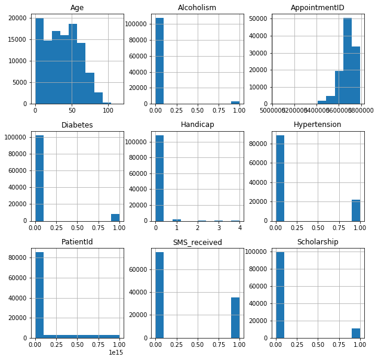

```python
df.hist(figsize=(10,10));
```

It is apparent that most patients don't have a handicap, alcoholism. so these two factors are not relevant in this analyis. on the other hand some patients recieved sms and some of them have hypertension.

# Do the following factors have any impact on the patients that are absent (Hypertension, SMS,Gender )?

Filtering to create a dataset for the absent patients only.

```python
Absent = df.query('No_show == "Yes"')
```

```python
Absent.head()
```

|  | PatientId | AppointmentID | Gender | ScheduledDay | AppointmentDay | Age | Neighbourhood | Scholarship | Hypertension | Diabetes | Alcoholism | Handicap | SMS_received | No_show | wait_time |
| --- | --- | --- | --- | --- | --- | --- | --- | --- | --- | --- | --- | --- | --- | --- | --- |
| 6 | 733688164476661 | 5630279 | F | 2016-04-27 | 2016-04-29 | 23 | GOIABEIRAS | 0 | 0 | 0 | 0 | 0 | 0 | Yes | 2 days |
| 7 | 3449833394123 | 5630575 | F | 2016-04-27 | 2016-04-29 | 39 | GOIABEIRAS | 0 | 0 | 0 | 0 | 0 | 0 | Yes | 2 days |
| 11 | 7542951368435 | 5620163 | M | 2016-04-26 | 2016-04-29 | 29 | NOVA PALESTINA | 0 | 0 | 0 | 0 | 0 | 1 | Yes | 3 days |
| 17 | 14794966191172 | 5633460 | F | 2016-04-28 | 2016-04-29 | 40 | CONQUISTA | 1 | 0 | 0 | 0 | 0 | 0 | Yes | 1 days |
| 20 | 622257462899397 | 5626083 | F | 2016-04-27 | 2016-04-29 | 30 | NOVA PALESTINA | 0 | 0 | 0 | 0 | 0 | 0 | Yes | 2 days |

Filtering to create a dataset for the present patients only.

```python
showed_up = df.query('No_show == "No"')
```

```python
showed_up.head()
```

|  | PatientId | AppointmentID | Gender | ScheduledDay | AppointmentDay | Age | Neighbourhood | Scholarship | Hypertension | Diabetes | Alcoholism | Handicap | SMS_received | No_show | wait_time |
| --- | --- | --- | --- | --- | --- | --- | --- | --- | --- | --- | --- | --- | --- | --- | --- |
| 0 | 29872499824296 | 5642903 | F | 2016-04-29 | 2016-04-29 | 62 | JARDIM DA PENHA | 0 | 1 | 0 | 0 | 0 | 0 | No | 0 days |
| 1 | 558997776694438 | 5642503 | M | 2016-04-29 | 2016-04-29 | 56 | JARDIM DA PENHA | 0 | 0 | 0 | 0 | 0 | 0 | No | 0 days |
| 2 | 4262962299951 | 5642549 | F | 2016-04-29 | 2016-04-29 | 62 | MATA DA PRAIA | 0 | 0 | 0 | 0 | 0 | 0 | No | 0 days |
| 3 | 867951213174 | 5642828 | F | 2016-04-29 | 2016-04-29 | 8 | PONTAL DE CAMBURI | 0 | 0 | 0 | 0 | 0 | 0 | No | 0 days |
| 4 | 8841186448183 | 5642494 | F | 2016-04-29 | 2016-04-29 | 56 | JARDIM DA PENHA | 0 | 1 | 1 | 0 | 0 | 0 | No | 0 days |

Counting the Gender(M/F) in the absent patients and calculating the percentage of those from the whole sample.

```python
Absent['Gender'].value_counts()
```

```
F    14591
M     7723
Name: Gender, dtype: int64
```

```python
df['Gender'].value_counts()
```

```
F    71836
M    38685
Name: Gender, dtype: int64
```

Finding the size of the whole sample.

```python
male = (7723/38685)*100
female = (14591 / 71836) * 100
Absent_Count=Absent['No_show'].value_counts()
print(Absent_Count)
```

```
Yes    22314
Name: No_show, dtype: int64
```

plotting a pie chart between the two new variables.

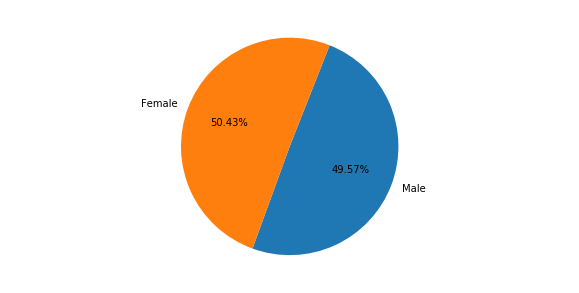

```python
plt.figure(figsize=(10, 5))
plt.axis("equal")
plt.pie([male, female], labels=["Male", "Female"],startangle=250, autopct='%2.2f%%');
```

It seems that more females missed their appointments than the males (50.43% to 49.57%)

```python
def plotpie(column, title):
    df[column].value_counts().plot(figsize=(5,5),kind='pie',autopct='%.2f');
    plt.title(title)
```

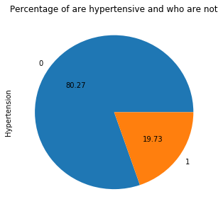

```python
plotpie(column='Hypertension',title='Percentage of are hypertensive and who are not');
```

It seems that a large percentage of the sample have hypertension,more analysis on this particular factor below.

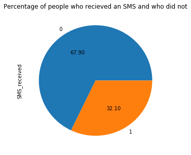

```python
plotpie(column='SMS_received',title='Percentage of people who recieved an SMS and who did not');
```

It seems that a large percentage of the sample have recieved an SMS, more analysis on this particular factor below.

Filtering the dataset with the next variable the sms.

```python
sms_recieved= df.query('SMS_received == "1"')
sms_recieved['SMS_received'].value_counts()
```

```
1    35482
Name: SMS_received, dtype: int64
```

Filtering the new data set by the absence and showing up.

```python
absent_R = sms_recieved.query('No_show == "Yes"')
absent_R['No_show'].value_counts()
```

```
Yes    9784
Name: No_show, dtype: int64
```

```python
showedup_R = sms_recieved.query('No_show == "No"')
showedup_R['No_show'].value_counts()
```

```
No    25698
Name: No_show, dtype: int64
```

Calculating the percentage of both and plotting the a bar chart.

```python
per_absent_R = (9784/35482) * 100
per_showedup_R = (25698/35482) * 100
```

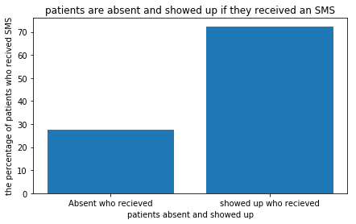

```python
plt.figure(figsize=(7, 4))
plt.bar(['Absent who recieved', 'showed up who recieved'], [per_absent_R, per_showedup_R]);
plt.title("patients are absent and showed up if they received an SMS");
plt.xlabel("patients absent and showed up")
plt.ylabel("the percentage of patients who recived SMS");
```

Filtering the dataset for the people who have hypertension.

```python
Hyp_group = df.query('Hypertension == "1"')
Hyp_group['Hypertension'].value_counts()
```

```
1    21801
Name: Hypertension, dtype: int64
```

Creating to data sets with people who were absent and showed up and calculating the percentage with regard to the whole sample.

```python
absent_hyp= Hyp_group.query('No_show == "Yes"')
absent_hyp['No_show'].value_counts()
```

```
Yes    3772
Name: No_show, dtype: int64
```

```python
showedup_hyp = Hyp_group.query('No_show == "No"')
showedup_hyp['No_show'].value_counts()
```

[output not shown]

```python
per_absent_hyp = (3772/21801) * 100
per_showedup_hyp = (18029/21801) * 100
```

It seems that people who have hypertension are more likely to be on their appointment, probably due to the fear as hypertension is known to be the silent killer.

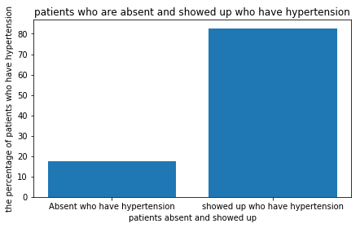

```python
plt.figure(figsize=(7, 4))
plt.bar(['Absent who have hypertension', 'showed up who have hypertension'], [per_absent_hyp, per_showedup_hyp]);
plt.title("patients who are absent and showed up who have hypertension");
plt.xlabel("patients absent and showed up")
plt.ylabel("the percentage of patients who have hypertension");
```

# what are the factors that helped patients come ?

what is the area with the highest number of absences ? does the waiting time impact patients who arrived ?

Finding the area with highest amount of absences.

```python
Areas = Absent.query('No_show == "Yes"')
Areas['Neighbourhood'].value_counts().head()
```

```
JARDIM CAMBURI    1465
MARIA ORTIZ       1219
ITARARÉ            923
RESISTÊNCIA        905
CENTRO             703
Name: Neighbourhood, dtype: int64
```

Creating a new dataset to see if the less the waiting the more likely the patients to attend the appointment.

```python
wait_time_0 = df.query('wait_time == "0"')
wait_time_0['No_show'].value_counts()
total = 36770 + 1792
print(total)
```

```
38562
```

Filtering the data set by absensce and showing up.

```python
showedup_w = wait_time_0.query('No_show == "No"')
showedup_w['No_show'].value_counts()
pre_show_w = (36770/38562)/38562 * 100
```

```python
absent_w = wait_time_0.query('No_show == "Yes"')
absent_w['No_show'].value_counts()
pre_absent_w = (1792/38562)/38562 * 100
```

It seems that the patients who have had the least amount of waiting time the more they managed to not miss the appointment.

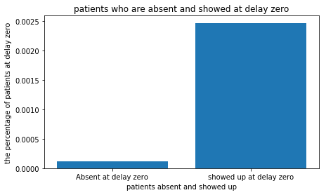

```python
plt.figure(figsize=(7, 4))
plt.bar(['Absent at delay zero', 'showed up at delay zero'], [pre_absent_w , pre_show_w]);
plt.title("patients who are absent and showed at delay zero");
plt.xlabel("patients absent and showed up")
plt.ylabel("the percentage of patients at delay zero");
```

## Conclusions

### Limitations

```python
from subprocess import call
call(['python', '-m', 'nbconvert', 'Investigate_a_Dataset.ipynb'])
```

```
0
```